# Battle of Neighborhoods

## Introduction

ABC Petrol Company wants to launch a Petrol pump in some locality in Chennai, a populous metro-politician city in India. The company approaches me to suggest the best location for the new petrol pump so that the profitability can be increased.

## Problem Background:

To suggest the best locality for ABC Petrol company, we need to gather the localities of Chennai city and analyze the places where target customers are high in numbers so that the company can gain more profit.

## Problem Description:

In order to find the suitable place to launch a petrol pump we need to analyze the neighborhood localities in Chennai city and apply the following logics.

1. The primary logic is to identify the roads connecting highways and localities with higher number of offices and buildings.
2. The secondary logic is to find the locations of other petrol pumps and the locality with sparse number of petrol pumps will have higher opportunity to grab the attention of petrol consumers.

## Data Section:

ABC Petrol Company wants to launch a Petrol pump in some locality in Chennai city. The company approaches me to suggest the best location for the new petrol pump so that the profitability can be increased.

So, for this problem, we must collect the geo-coordinates of the neighborhood localities in the city of Chennai and as well as the geo-coordinates of Offices, other petrol pumps and the roads (meeting junctions) where the motion of vehicles is quite more.

## Data description:

The following table has the details of the datasets used for the given problem.

| **S.No** |  | **File Name** |  |  | **Description** |  |
| --- | --- | --- | --- | --- | --- | --- |
| 1. |  | localities_ | This file contains the name, latitude and longitude (geo-coordinates) of the |  |  |  |
|  |  | coords | localities in and around the city of Chennai. |  |  |  |
| 2. |  | chief_centers | This comma separated valued file has four columns: |  |  |  |
|  |  |  | a. | Name of the which is considered to be one of the chief centers in |  |  |
|  |  |  |  | Chennai city, having chief petrol consumers |  |  |
|  |  |  | b. | Latitude of the place |  |  |
|  |  |  | c. | Longitude of the place |  |  |
|  |  |  | d. | Type of place – It contains the label of the place of which category |  |  |
|  |  |  |  | it belongs to (example: School, Office, Petrol Pump, Others) |  |  |
| 3. |  | transport_ | This file contains the latitude, longitude and the traffic intensity (based on |  |  |  |
|  |  | coords | the motion of vehicles in the road) which ranges from 0-1 where: |  |  |  |
|  |  |  | 0 – No traffic |  |  |  |
|  |  |  | 1 – Full traffic |  |  |  |

## Data Sources:

1. https://github.com/mathan-madhav/coursera/blob/master/data_localities_coords.csv
2. https://github.com/mathan-madhav/coursera/blob/master/data_chief_centers.csv
3. https://github.com/mathan-madhav/coursera/blob/master/data_transport_coords.csv

## Fetch Data

```python
## Import Section

import pandas as pd
import io
import requests
import matplotlib.pyplot as plt
```

```python
# Fetch Localities data

url = 'https://github.com/mathan-madhav/coursera/blob/master/data_localities_coords.csv'
s=requests.get(url).content
localities=dict(pd.read_csv(io.StringIO(s.decode('utf-8'))))
print(localities)
```

```
{'Neighborhood location': ('Latitude', 'Longitude'),
 'Adambakkam': ('12.80208', '77.01361'),
 'Adyar': ('10.36934', '77.44018'),
 'Alandur': ('11.86331', '77.98423'),
 'Alapakkam': ('16.75254', '78.08717'),
 'Alwarpet': ('10.24068', '78.82594'),
 'Alwarthirunagar': ('14.31992', '77.67651'),
 'Ambattur': ('15.60714', '77.24921'),
 'Aminjikarai': ('12.47913', '77.21502'),
 'Anna Nagar': ('15.20593', '77.4858'),
 'Annanur': ('15.59708', '78.7907'),
 'Arumbakkam': ('15.25872', '78.24754'),
 'Ashok Nagar': ('11.57055', '78.7764'),
 'Avadi': ('12.21563', '78.99931'),
 'Ayanavaram': ('13.54762', '77.61998'),
 'Besant Nagar': ('10.27383', '78.16746'),
 'Basin Bridge': ('16.98263', '78.66912'),
 'Chepauk': ('14.60056', '77.12942'),
 'Chetput': ('11.68193', '77.78686'),
 'Chintadripet': ('16.36302', '78.50726'),
 'Chitlapakkam': ('10.22278', '78.62786'),
 'Choolai': ('14.65206', '78.88645'),
 'Choolaimedu': ('16.36233', '77.86339'),
 'Chrompet': ('16.2859', '77.64526'),
 'Egmore': ('15.98082', '78.26191'),
 'Ekkaduthangal': ('15.64847', '77.78738'),
 'Ennore': ('10.91055', '77.52851'),
 'Foreshore Estate': ('10.84808', '77.06359'),
 'Fort St. George': ('14.03423', '77.21661'),
 'George Town': ('13.22998', '77.89945'),
 'Gopalapuram': ('13.12349', '78.98205'),
 'Government Estate': ('12.02326', '78.53868'),
 'Guindy': ('15.01762', '78.45979'),
 'Gerugambakkam': ('16.75705', '77.32053'),
 'IIT Madras': ('15.40008', '78.41759'),
 'Injambakkam': ('16.24947', '78.47464'),
 'ICF': ('15.15703', '77.14681'),
 'Iyyapanthangal': ('12.57363', '78.8802'),
 'Jafferkhanpet': ('11.73606', '78.1994'),
 'Karapakkam': ('13.47123', '77.09352'),
```

[output cut: 102 more lines]

```
 'Tirusulam': ('15.95688', '78.2458'),
 'Tiruvallikeni': ('15.92579', '78.2609'),
 'Tondiarpet': ('16.1678', '78.4653'),
 'United India Colony': ('13.67375', '77.0992'),
 'Vandalur': ('12.515', '78.7626'),
 'Vadapalani': ('13.18479', '78.4304'),
 'Valasaravakkam': ('14.71205', '78.2123'),
 'Vallalar Nagar': ('16.67115', '78.2992'),
 'Vanagaram': ('13.14773', '78.5708'),
 'Velachery': ('11.99882', '78.4217'),
 'Villivakkam': ('10.43019', '78.7995'),
 'Virugambakkam': ('12.93924', '77.3053'),
 'Vyasarpadi': ('15.37999', '78.5539'),
 'Washermanpet': ('14.55423', '78.719'),
 'West Mambalam': ('12.50267', '77.6137')}
```

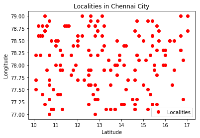

```python
# Visualize Localities

locality_x = []
locality_y = []

# Get Latitude and Longitude

for loc in localities.keys():
    locality_x.append(localities[loc][0])
    locality_y.append(localities[loc][1])

# Round up the data for effective visualization

locality_x = [round(float(i),1) for i in locality_x[1:len(locality_x)]]
locality_y = [round(float(i),1) for i in locality_y[1:len(locality_y)]]

# Draw maps

ax=plt.gca()
plt.xlabel('Latitude')
plt.ylabel('Longitude')

plt.plot(locality_x,locality_y,'ro',label='Localities')
plt.legend(loc='best')
plt.title('Localities in Chennai City')
```

```python
# Fetch Chief centers

url = 'https://github.com/mathan-madhav/coursera/blob/master/data_chief_centers.csv'
s=requests.get(url).content
centers=dict(pd.read_csv(io.StringIO(s.decode('utf-8'))))
print(centers)
```

```
{'Name of the Place': ['Type of Place', 'Latitude', 'Longitude'],
 'Aavin': ['Office', '13.45498907', '77.12275104'],
 'Aban Offshore': ['Petrol pump', '12.23070646', '78.20708142'],
 'Accel Transmatic': ['Office', '10.29360831', '78.28834965'],
 'Adarsh Vidyalaya': ['School', '15.06201037', '78.03216953'],
 'Adyar Ananda Bhavan': ['Office', '11.43956485', '77.2545691'],
 'Ahmedabad One': ['Others', '12.69110306', '77.25947002'],
 'Akshar Arbol International School': ['School', '15.76847944', '78.65410382'],
 'AlphaOne Mall': ['Others', '12.03129821', '78.20485795'],
 'Amalgamations Group': ['Office', '16.76697077', '77.07671979'],
 'Aman Petrol Station': ['Petrol pump', '10.95338524', '78.65326318'],
 'Amara Muzik': ['Office', '13.94756084', '78.42727131'],
 'Amco Batteries': ['Office', '15.01737081', '77.27388996'],
 'American International School Chennai': ['School',
  '12.29345667',
  '78.14942318'],
 'AMM Matriculation Higher Secondary School': ['School',
  '13.30848329',
  '78.12982394'],
 'Amrutanjan Healthcare': ['Office', '16.34931188', '77.19497835'],
 'Amulya Petrol Station': ['Petrol pump', '13.78978965', '77.97765888'],
 'Anabond': ['Office', '12.40154914', '77.15413416'],
 'Ananda Vikatan': ['Office', '12.89124553', '77.03024511'],
 'Anjappar Chettinad Restaurant': ['Office', '13.86386624', '77.78023708'],
 'Apollo Hospitals': ['Office', '13.95642405', '77.95265374'],
 'Arogyam Petrol Station': ['Petrol pump', '10.82276054', '78.21563818'],
 'Aroma Petrol Station': ['Petrol pump', '13.18775296', '77.75715382'],
 'Asan Memorial Senior Secondary School': ['School',
  '10.97019984',
  '77.31231217'],
 'Ashok Leyland': ['Office', '12.36678831', '78.51762868'],
 'Ashok Leyland Defence Systems': ['Office', '10.73710856', '77.09909415'],
 'Babaji Vidhyashram': ['School', '15.63738193', '77.83444159'],
 'Bamini': ['Office', '15.09410186', '78.8535962'],
 'Bank of Chettinad': ['Office', '11.61884895', '77.14141289'],
 'Bank of Madras': ['Office', '10.74970559', '78.51320866'],
 'Bank of Madura': ['Office', '14.10151342', '77.49308864'],
 'BankBazaar': ['Office', '14.2183805', '78.53499819'],
 'Basin Bridge Gas Turbine Power Station': ['Office',
  '15.09246774',
```

[output cut: 484 more lines]

```
  '78.77866417'],
 'Vinveli': ['Office', '12.37046744', '77.06089175'],
 'Viviana Mall': ['Others', '16.99287981', '78.98336795'],
 'VR Bengaluru': ['Others', '11.13867783', '77.14696988'],
 'Vyasa Vidyalaya Matriculation Higher Secondary School': ['School',
  '10.08170034',
  '77.30339375'],
 'Wesley Higher Secondary School': ['School', '10.06117632', '78.0979518'],
 'Wind Petrol Station': ['Petrol pump', '12.75505188', '78.32069727'],
 'World Trade Park': ['Others', '15.9871281', '78.1680885'],
 'YAW Petrol Station': ['Petrol pump', '10.97292027', '77.66580303'],
 'Z Petrol Station': ['Petrol pump', '16.32282323', '77.57853181'],
 'Z Square Mall': ['Others', '13.35123523', '77.44358632'],
 'Zebra Petrol Station': ['Petrol pump', '15.56707127', '77.28854365'],
 'Zoho Corporation': ['Office', '14.66262019', '77.25180079']}
```

[figure not shown]

```python
# Visualize City Centers

center_x = []
center_y = []

# Get Latitude and Longitude

for center in centers.keys():
    center_x.append(centers[center][1])
    center_y.append(centers[center][2])

# Round up the data for effective visualization

center_x = [round(float(i),1) for i in locality_x[1:len(center_x)]]
center_y = [round(float(i),1) for i in locality_y[1:len(center_y)]]

# Draw maps

ax=plt.gca()
plt.xlabel('Latitude')
plt.ylabel('Longitude')

plt.plot(center_x,center_y,'g+',label='City Centers')
plt.legend(loc='best')
plt.title('City centers in Chennai City')
```

```python
# Fetch Transport Co-ords

url = 'https://raw.githubusercontent.com/mathan-madhav/coursera/master/data_transport_coords.csv'
s=requests.get(url).content
transport=dict(pd.read_csv(io.StringIO(s.decode('utf-8'))))
print(transport)
```

```
{'Road Junctions': ['Latitude', 'Longitude', 'Traffic Intensity'],
 'Airport Junction': ['15.88977179', '78.21264686', '0.2454'],
 'Alwarpet Junction': ['13.27996878', '77.67554232', '0.1534'],
 'Anna Arch Junction - Arumbakkam': ['13.19023785', '78.85456975', '0.2929'],
 'Anna Arch Junction Aminjikarai': ['16.80221717', '78.44076536', '0.5438'],
 'Anna Junction': ['11.33614244', '78.26963008', '0.5424'],
 'Chrompet Junction': ['13.58287141', '77.35069896', '0.5137'],
 'Conran Smith Road Junction': ['10.45961901', '78.62854647', '0.3446'],
 'Doveton Junction': ['14.55380638', '77.98810011', '0.2466'],
 'Dr. Radhakrishnan Road Junction': ['14.21072944', '78.89456106', '0.7883'],
 'G N Chetty Road Junction': ['14.86047769', '77.37238358', '0.3214'],
 'IIT Madras Junction': ['13.68778127', '77.15970215', '0.6844'],
 'Kathipara grade separator': ['16.26951543', '77.91656503', '0.9269'],
 'Keelkattalai Junction': ['15.47883226', '78.37663373', '0.8738'],
 'Kilkattalai - Pallavaram Radial Road Junction': ['14.51253004',
  '77.65374093',
  '0.3669'],
 'Koyambedu CMBT Junction': ['14.21290434', '77.29119832', '0.0997'],
 'Koyambedu grade separator': ['10.00881712', '77.34400229', '0.8833'],
 'Madhuravoyal grade separator': ['10.25358262', '77.3561813', '0.9357'],
 'Mahalingapuram Junction': ['10.72996981', '78.92558675', '0.5017'],
 'Medavakkam Junction': ['11.94667538', '77.25831502', '0.3438'],
 'Mint Junction': ['14.54616591', '77.09602515', '0.962'],
 'Moolakkadai Junction': ['16.92679694', '78.75898966', '0.2254'],
 'Music Academy Junction': ['11.53778439', '77.84451794', '0.8319'],
 'Padi grade separator': ['12.39149005', '77.99688986', '0.4256'],
 'Pallavaram Radial Road - GST Junction': ['13.2474627',
  '78.48234064',
  '0.7093'],
 'Panagal Park Junction': ['10.50945441', '78.7681446', '0.8204'],
 'Pantheon Road Junction': ['13.55783103', '78.32460721', '0.1226'],
 'Perambur Junction': ['10.05355151', '77.01431753', '0.563'],
 'Peters Road Junction': ['13.22985088', '78.3865562', '0.9606'],
 'Porur Junction': ['14.73959231', '77.30626088', '0.7777'],
 'Tambaram Junction': ['10.90081305', '77.7862407', '0.5867'],
 'Tambaram Sanitorium (Bharatha Matha Street) Junction': ['14.62212198',
  '78.45514118',
  '0.0807'],
 'Thirumangalam Junction': ['10.30776627', '78.81110646', '0.2627'],
 'Thiruvanmiyur Junction': ['14.97518875', '77.23341402', '0.3244'],
 'TTK Road Junction': ['13.80684761', '78.20626572', '0.9315'],
 'Vadapalani Junction Junction': ['10.27202403', '78.23785877', '0.694'],
 'Vandalur Junction': ['11.97485733', '78.90151337', '0.6942'],
 'Velachery Junction Junction': ['11.99855703', '78.96727251', '0.6218'],
 'Velachery Taramani Road - Kamakshi Hospital Junction': ['14.26044677',
  '77.7195237',
  '0.0508'],
 'Vyasarpadi Junction': ['16.37544821', '77.90826733', '0.0183']}
```

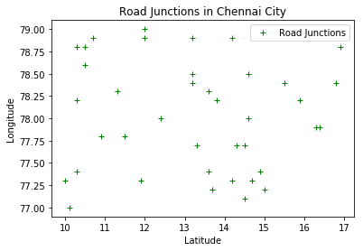

```python
# Visualize Road Junctions

trans_x = []
trans_y = []

# Get Latitude and Longitude

for trans in transport.keys():
    trans_x.append(transport[trans][0])
    trans_y.append(transport[trans][1])

# Round up the data for effective visualization

trans_x = [round(float(i),1) for i in trans_x[1:len(trans_x)]]
trans_y = [round(float(i),1) for i in trans_y[1:len(trans_y)]]

# Draw maps

ax=plt.gca()
plt.xlabel('Latitude')
plt.ylabel('Longitude')

plt.plot(trans_x,trans_y,'g+',label='Road Junctions')
plt.legend(loc='best')
plt.title('Road Junctions in Chennai City')
```

## Feature Extraction from Data:

The following features can be extracted from the data sources to solve the problem.

### Type of the place

Office -> +1.0  
Schools -> +0.5  
Petrol Pumps -> -1.0  
Others (like Shopping Malls)-> +0.5

### Traffic Intensity

0.0 to 0.25 -> -1.0  
0.25 to 0.5 -> -0.5  
0.5 to 0.75 -> +0.5  
0.75 to 1.0 -> +1.0

### Note:

Negative values indicate that the least likelihood of the locality to open the petrol pump whereas the positive values are more likelihood values for opening the petrol pumps in that particular locality.

```python
# Create Weight Mapping Table

weight_mapping={}
places = ['Office','School','Petrol pump','Others']
weights = [1,0.5,-1,0.5]
for place in places:
    if place not in weight_mapping.keys():
        weight_mapping[place]=weights[places.index(place)]

# Display mapping table

weight_mapping
```

```
{'Office': 1, 'School': 0.5, 'Petrol pump': -1, 'Others': 0.5}
```

```python
# Create Weight Mapping for Traffic Intenstities

junctions = [i for i in transport.keys()]
t_intensity = [i[-1] for i in transport.items()]
transport[junctions[0]].append('Weight')

# Util function to map weights

def find_weight(w):
    w=float(w)
    if w < 0.25:
        return -1
    elif w < 0.5:
        return -0.5
    elif w < 0.75:
        return 0.5
    else:
        return 1

# Update weights

for junction in junctions[1:len(junctions)]:
    transport[junction].append(find_weight(transport[junction][-1])) # last column is traffic intensity

# Display changes

transport
```

```
{'Road Junctions': ['Latitude', 'Longitude', 'Traffic Intensity', 'Weight'],
 'Airport Junction': ['15.88977179', '78.21264686', '0.2454', -1],
 'Alwarpet Junction': ['13.27996878', '77.67554232', '0.1534', -1],
 'Anna Arch Junction - Arumbakkam': ['13.19023785',
  '78.85456975',
  '0.2929',
  -0.5],
 'Anna Arch Junction Aminjikarai': ['16.80221717',
  '78.44076536',
  '0.5438',
  0.5],
 'Anna Junction': ['11.33614244', '78.26963008', '0.5424', 0.5],
 'Chrompet Junction': ['13.58287141', '77.35069896', '0.5137', 0.5],
 'Conran Smith Road Junction': ['10.45961901', '78.62854647', '0.3446', -0.5],
 'Doveton Junction': ['14.55380638', '77.98810011', '0.2466', -1],
 'Dr. Radhakrishnan Road Junction': ['14.21072944',
  '78.89456106',
  '0.7883',
  1],
 'G N Chetty Road Junction': ['14.86047769', '77.37238358', '0.3214', -0.5],
 'IIT Madras Junction': ['13.68778127', '77.15970215', '0.6844', 0.5],
 'Kathipara grade separator': ['16.26951543', '77.91656503', '0.9269', 1],
 'Keelkattalai Junction': ['15.47883226', '78.37663373', '0.8738', 1],
 'Kilkattalai - Pallavaram Radial Road Junction': ['14.51253004',
  '77.65374093',
  '0.3669',
  -0.5],
 'Koyambedu CMBT Junction': ['14.21290434', '77.29119832', '0.0997', -1],
 'Koyambedu grade separator': ['10.00881712', '77.34400229', '0.8833', 1],
 'Madhuravoyal grade separator': ['10.25358262', '77.3561813', '0.9357', 1],
 'Mahalingapuram Junction': ['10.72996981', '78.92558675', '0.5017', 0.5],
 'Medavakkam Junction': ['11.94667538', '77.25831502', '0.3438', -0.5],
 'Mint Junction': ['14.54616591', '77.09602515', '0.962', 1],
 'Moolakkadai Junction': ['16.92679694', '78.75898966', '0.2254', -1],
 'Music Academy Junction': ['11.53778439', '77.84451794', '0.8319', 1],
 'Padi grade separator': ['12.39149005', '77.99688986', '0.4256', -0.5],
 'Pallavaram Radial Road - GST Junction': ['13.2474627',
  '78.48234064',
  '0.7093',
  0.5],
 'Panagal Park Junction': ['10.50945441', '78.7681446', '0.8204', 1],
 'Pantheon Road Junction': ['13.55783103', '78.32460721', '0.1226', -1],
 'Perambur Junction': ['10.05355151', '77.01431753', '0.563', 0.5],
 'Peters Road Junction': ['13.22985088', '78.3865562', '0.9606', 1],
 'Porur Junction': ['14.73959231', '77.30626088', '0.7777', 1],
 'Tambaram Junction': ['10.90081305', '77.7862407', '0.5867', 0.5],
 'Tambaram Sanitorium (Bharatha Matha Street) Junction': ['14.62212198',
  '78.45514118',
  '0.0807',
  -1],
 'Thirumangalam Junction': ['10.30776627', '78.81110646', '0.2627', -0.5],
 'Thiruvanmiyur Junction': ['14.97518875', '77.23341402', '0.3244', -0.5],
 'TTK Road Junction': ['13.80684761', '78.20626572', '0.9315', 1],
 'Vadapalani Junction Junction': ['10.27202403', '78.23785877', '0.694', 0.5],
 'Vandalur Junction': ['11.97485733', '78.90151337', '0.6942', 0.5],
 'Velachery Junction Junction': ['11.99855703', '78.96727251', '0.6218', 0.5],
 'Velachery Taramani Road - Kamakshi Hospital Junction': ['14.26044677',
  '77.7195237',
  '0.0508',
  -1],
 'Vyasarpadi Junction': ['16.37544821', '77.90826733', '0.0183', -1]}
```

```python
# Update Weights of city centers

#c_centers = [i for i in centers.keys()]
#type_of_place = [i[1][0] for i in centers.items()]
#centers[c_centers[0]].append('Weight')

for center in c_centers[1:len(c_centers)]:
    centers[center].append(weight_mapping[centers[center][0]])

# Display Changes

centers
```

```
{'Name of the Place': ['Type of Place', 'Latitude', 'Longitude', 'Weight'],
 'Aavin': ['Office', '13.45498907', '77.12275104', 1],
 'Aban Offshore': ['Petrol pump', '12.23070646', '78.20708142', -1],
 'Accel Transmatic': ['Office', '10.29360831', '78.28834965', 1],
 'Adarsh Vidyalaya': ['School', '15.06201037', '78.03216953', 0.5],
 'Adyar Ananda Bhavan': ['Office', '11.43956485', '77.2545691', 1],
 'Ahmedabad One': ['Others', '12.69110306', '77.25947002', 0.5],
 'Akshar Arbol International School': ['School',
  '15.76847944',
  '78.65410382',
  0.5],
 'AlphaOne Mall': ['Others', '12.03129821', '78.20485795', 0.5],
 'Amalgamations Group': ['Office', '16.76697077', '77.07671979', 1],
 'Aman Petrol Station': ['Petrol pump', '10.95338524', '78.65326318', -1],
 'Amara Muzik': ['Office', '13.94756084', '78.42727131', 1],
 'Amco Batteries': ['Office', '15.01737081', '77.27388996', 1],
 'American International School Chennai': ['School',
  '12.29345667',
  '78.14942318',
  0.5],
 'AMM Matriculation Higher Secondary School': ['School',
  '13.30848329',
  '78.12982394',
  0.5],
 'Amrutanjan Healthcare': ['Office', '16.34931188', '77.19497835', 1],
 'Amulya Petrol Station': ['Petrol pump', '13.78978965', '77.97765888', -1],
 'Anabond': ['Office', '12.40154914', '77.15413416', 1],
 'Ananda Vikatan': ['Office', '12.89124553', '77.03024511', 1],
 'Anjappar Chettinad Restaurant': ['Office', '13.86386624', '77.78023708', 1],
 'Apollo Hospitals': ['Office', '13.95642405', '77.95265374', 1],
 'Arogyam Petrol Station': ['Petrol pump', '10.82276054', '78.21563818', -1],
 'Aroma Petrol Station': ['Petrol pump', '13.18775296', '77.75715382', -1],
 'Asan Memorial Senior Secondary School': ['School',
  '10.97019984',
  '77.31231217',
  0.5],
 'Ashok Leyland': ['Office', '12.36678831', '78.51762868', 1],
 'Ashok Leyland Defence Systems': ['Office', '10.73710856', '77.09909415', 1],
 'Babaji Vidhyashram': ['School', '15.63738193', '77.83444159', 0.5],
 'Bamini': ['Office', '15.09410186', '78.8535962', 1],
```

[output cut: 613 more lines]

```
 'Vyasa Vidyalaya Matriculation Higher Secondary School': ['School',
  '10.08170034',
  '77.30339375',
  0.5],
 'Wesley Higher Secondary School': ['School',
  '10.06117632',
  '78.0979518',
  0.5],
 'Wind Petrol Station': ['Petrol pump', '12.75505188', '78.32069727', -1],
 'World Trade Park': ['Others', '15.9871281', '78.1680885', 0.5],
 'YAW Petrol Station': ['Petrol pump', '10.97292027', '77.66580303', -1],
 'Z Petrol Station': ['Petrol pump', '16.32282323', '77.57853181', -1],
 'Z Square Mall': ['Others', '13.35123523', '77.44358632', 0.5],
 'Zebra Petrol Station': ['Petrol pump', '15.56707127', '77.28854365', -1],
 'Zoho Corporation': ['Office', '14.66262019', '77.25180079', 1]}
```

```python
# Collect Latitude and Longitudes

locality_x = []
locality_y = []

center_x = []
center_y = []
w1 = []

trans_x = []
trans_y = []
w2 = []

# Get Latitude and Longitude

for loc in localities.keys():
    locality_x.append(localities[loc][0])
    locality_y.append(localities[loc][1])

for center in centers.keys():
    center_x.append(centers[center][1])
    center_y.append(centers[center][2])
    w1.append(centers[center][-1])

for trans in transport.keys():
    trans_x.append(transport[trans][0])
    trans_y.append(transport[trans][1])
    w2.append(transport[trans][-1])

# Round up the data for effective visualization

locality_x = [round(float(i),1) for i in locality_x[1:len(locality_x)]]
locality_y = [round(float(i),1) for i in locality_y[1:len(locality_y)]]
center_x   = [round(float(i),1) for i in center_x[1:len(center_x)]]
center_y   = [round(float(i),1) for i in center_y[1:len(center_y)]]
trans_x    = [round(float(i),1) for i in trans_x[1:len(trans_x)]]
trans_y    = [round(float(i),1) for i in trans_y[1:len(trans_y)]]
```

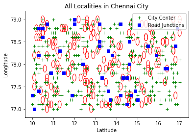

```python
# Draw maps

ax=plt.gca()
plt.xlabel('Latitude')
plt.ylabel('Longitude')

for i in range(len(locality_x)):
    circle = plt.Circle((locality_x[i],locality_y[i]),radius=0.08,fill=False,color='r')
    ax.add_patch(circle)
plt.plot(center_x,center_y,'g+',label='City Center')
plt.plot(trans_x,trans_y,'bs',label='Road Junctions')
plt.legend(loc='best')
plt.title('All Localities in Chennai City')

# Note
#    * The encircled in red color are the localities
```

# Draw heat map showing the weight scores

[figure not shown]

```python
import numpy as np
import seaborn as sns

x = np.arange(min(locality_x),max(locality_x),0.1)
y = np.arange(min(locality_y),max(locality_y),0.1)

zone=[]
for i in x:
    for j in y:
        zone.append(weight[i][j])

ax = sns.heatmap(zone, linewidth=0.5)

# We want to show all ticks...

ax.set_xticks(np.arange(len(x)))
ax.set_yticks(np.arange(len(y)))

# and label them with the respective list entries

ax.set_xticklabels([str(i) for i in x])
ax.set_yticklabels([str(i) for i in y])

# Rotate the tick labels and set their alignment.

plt.setp(ax.get_xticklabels(), rotation=45, ha="right",
         rotation_mode="anchor")

plt.setp(ax.get_yticklabels(), rotation=45, ha="right",
         rotation_mode="anchor")

# set titles

ax.set_title("Heat map showing city centers in Chennai City")
fig.tight_layout()
plt.xlabel('Latitude')
plt.ylabel('Longitude')

plt.show()
```

# Prediction Model

```python
from sklearn.cross_validation import train_test_split

train, test = train_test_split(localities, test_size = 0.4)
train = train.reset_index(drop=True)
test = test.reset_index(drop=True)

features_train = train[list(vif['Features'])]
label_train = train['target']
features_test = test[list(vif['Features'])]
label_test = test['target']
```

```python
from sklearn.ensemble import RandomForestClassifier
clf = RandomForestClassifier()

clf.fit(features_train,label_train)

pred_train = clf.predict(features_train)
pred_test = clf.predict(features_test)

from sklearn.metrics import accuracy_score
accuracy_train = accuracy_score(pred_train,label_train)
accuracy_test = accuracy_score(pred_test,label_test)

from sklearn import metrics
fpr, tpr, _ = metrics.roc_curve(np.array(label_train), clf.predict_proba(features_train)[:,1])
auc_train = metrics.auc(fpr,tpr)

fpr, tpr, _ = metrics.roc_curve(np.array(label_test), clf.predict_proba(features_test)[:,1])
auc_test = metrics.auc(fpr,tpr)
```

```python
# Hyper parameter tuning

from sklearn.model_selection import RandomizedSearchCV
from sklearn.ensemble import RandomForestClassifier

n_estimators = [int(x) for x in np.linspace(start = 10, stop = 500, num = 10)]
max_features = ['auto', 'sqrt']
max_depth = [int(x) for x in np.linspace(3, 10, num = 1)]
max_depth.append(None)
min_samples_split = [2, 5, 10]
min_samples_leaf = [1, 2, 4]
bootstrap = [True, False]

random_grid = {'n_estimators': n_estimators,
               'max_features': max_features,
               'max_depth': max_depth,
               'min_samples_split': min_samples_split,
               'min_samples_leaf': min_samples_leaf,
               'bootstrap': bootstrap}

rf = RandomForestClassifier()

rf_random = RandomizedSearchCV(estimator = rf, param_distributions = random_grid, n_iter = 10, cv = 2, verbose=2, random_state=42, n_jobs = -1)
rf_random.fit(features_train, label_train)
```

[figure not shown]

```python
# Cross tab

pd.crosstab(label_train,pd.Series(pred_train),rownames=['ACTUAL'],colnames=['PRED'])
```

[figure not shown]

```python
# ROC Curve

from bokeh.charts import Histogram
from ipywidgets import interact
from bokeh.plotting import figure
from bokeh.io import push_notebook, show, output_notebook
output_notebook()
from sklearn import metrics
preds = clf.predict_proba(features_train)[:,1]
fpr, tpr, _ = metrics.roc_curve(np.array(label_train), preds)
auc = metrics.auc(fpr,tpr)
p = figure(title="ROC Curve - Train data")
r = p.line(fpr,tpr,color='#0077bc',legend = 'AUC = '+ str(round(auc,3)), line_width=2)
s = p.line([0,1],[0,1], color= '#d15555',line_dash='dotdash',line_width=2)
show(p)
```

## Lift chart, Actual vs predicted chart, Gains chart

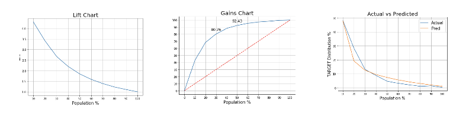

```python
gains(lift_train,['DECILE'],'TARGET','SCORE')
```

```python
# Calculate Scores

def find_score(features,clf):
    score = pd.DataFrame(clf.predict_proba(features)[:,1], columns = ['SCORE'])
    score['DECILE'] = pd.qcut(score['SCORE'].rank(method = 'first'),10,labels=range(10,0,-1))
    score['DECILE'] = score['DECILE'].astype(float)
    return(score)

p_scores = find_score(weights,clf)
```

# Discussion Section

The following recommendations can be included in addition to the existing methodology:

• The details of the distance between different city centers can be taken into account so that the petrol pump can be opened in the midst of any 2 centers with higher number of customers  
• Other secondary centers like Car Mechanic Shops, Automobile Repair Shops can be accounted based on the assumption that they may visit the petrol pump after repair.  
• Thirdly, the population density can be used. Lesser the density lower the chance of opening a petrol pump because the customers will not prefer to move from dense to sparsely populated region to fill petrol.

# Result Section

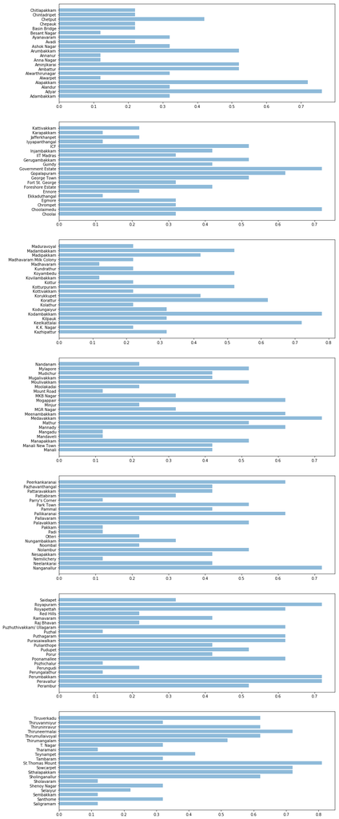

```python
# Draw plot of Locality vs prediction score

loc_names = [i for i in localities.keys()]

fig,ax = plt.subplots(len(loc_names)/20)

l=0 # index

# plot subplots

for i in range(len(loc_names)/20):
    ax[i].barh(loc_names[l:l+20], p_scores[l:l+20], align='center', alpha=0.5) # Split data set and visualize for better clarity
    l=l+20

plt.show()
```

# Conclusion

• Based on the prediction model and the methodology used, we come to a conclusion that opening a brand new petrol pump in the (1) St.Thomas Mount Locality (prediction score = 0.81) has the highest chance of making profit for the ABC company.  
• It is based on the fact that the chosen locality is populated with a lots of petrol consumers and it comprises various popular city centers like Shopping Malls, Road Junctions and have high traffic intensity in and around the locality.  
• Also, we can nominate the other equivalently eligible localities (2) Kodambakkam and (3) Adyar with same approximately prediction scores (0.78) and (0.76) respectively.  
• The Business team of ABC company can analyse among the top 3 localities with high prediction scores and they can come up with a locality to launch their new petrol pump.